# Practical Machine Learning-Prediction Assignment

EDE

24/07/2015

# Background

Using devices such as Jawbone Up, Nike FuelBand, and Fitbit it is now possible to collect a large amount of data about personal activity relatively inexpensively. These type of devices are part of the quantified self movement – a group of enthusiasts who take measurements about themselves regularly to improve their health, to find patterns in their behavior, or because they are tech geeks. One thing that people regularly do is quantify how much of a particular activity they do, but they rarely quantify how well they do it. In this project, your goal will be to use data from accelerometers on the belt, forearm, arm, and dumbell of 6 participants. They were asked to perform barbell lifts correctly and incorrectly in 5 different ways. More information is available from the website here: http://groupware.les.inf.puc-rio.br/har (see the section on the Weight Lifting Exercise Dataset).

# Data

The training data for this project are available here:

https://d396qusza40orc.cloudfront.net/predmachlearn/pml-training.csv

The test data are available here:

https://d396qusza40orc.cloudfront.net/predmachlearn/pml-testing.csv

## The data for this project come from this source: http://groupware.les.inf.puc-rio.br/har. If you use the document you create for this class for any purpose please cite them as they have been very generous in allowing their data to be used for this kind of assignment.

# load data

```r
outPutFile= "result.txt"
urlTrain = "https://d396qusza40orc.cloudfront.net/predmachlearn/pml-training.csv"
urlTest = "https://d396qusza40orc.cloudfront.net/predmachlearn/pml-testing.csv"

fileTrain="pml-training.csv"
fileTest='pml-testing.csv'

if (!file.exists(fileTrain)){
    download.file(url =urlTrain, destfile = fileTrain)
}
if (!file.exists(fileTest)){
    download.file(url =urlTest, destfile = fileTest)
}

DatafameTrain <- read.csv2(fileTrain,sep = ',')
DatafameTest <- read.csv2(fileTest,sep=',')
```

# prepare data

```r
table(DatafameTrain$classe)
```

```
##
##    A    B    C    D    E
## 5580 3797 3422 3216 3607
```

```r
trainIndex <- createDataPartition(DatafameTrain$classe,p=0.8,list=FALSE)

trainData = DatafameTrain[trainIndex ,]
validationData = DatafameTrain[-trainIndex ,]

epsilon <- nearZeroVar(trainData )
trainDataNZ <- trainData[-epsilon]
validationDataNZ <- validationData[-epsilon]
testDataNZ <-DatafameTest[-epsilon]


dim(trainDataNZ)
```

```
## [1] 15699   101
```

```r
dim(validationDataNZ)
```

```
## [1] 3923  101
```

```r
dim(testDataNZ)
```

```
## [1]  20 101
```

# cleaning data

```r
# input trainDataNZ validationDataNZ testDataNZ
# output  DFTrain<-train.Num DFTest<-DatafameTest DFValidate<-validation.Num
#----------------------------------------------------------------------------------------
# remove useless column
columnRm <- grep('^X|timestamp|window', names(trainData))

DF_T0 <- trainDataNZ[,-c(columnRm)]
DF_V0 <- validationDataNZ[,-c(columnRm)]

# remove column with NA value
DF_T1  <- DF_T0[, colSums(is.na(DF_T0)) == 0]
DF_V1 <- DF_V0[, colSums(is.na(DF_V0)) == 0]

# remove non numeric columb except class
classeSave <- DF_T1$classe
DFTrain <- DF_T1[,sapply(DF_T1, is.numeric)]
DFTrain$classe<-classeSave

classeSave <- DF_V1$classe
DFValidate <- DF_V1[,sapply(DF_V1, is.numeric)]
DFValidate$classe<-classeSave
```

# what data look like ?

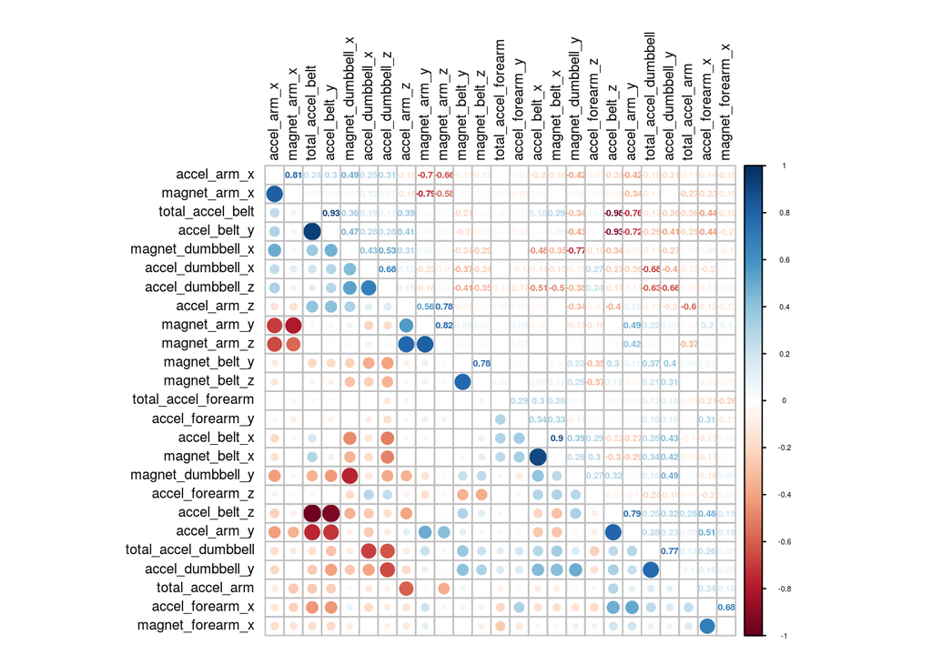

```r
predictor_corr <- round(cor(DFTrain[sapply(DFTrain, is.numeric)]), 2)


par(ps=5)
corrplot.mixed(predictor_corr, order = "hclust", tl.col="black", diag = "n", tl.pos = "lt",
               lower = "circle", upper = "number", tl.cex = 1.5, mar=c(1,0,1,0))
```

```r
# higher positively correlated are (darker blue)
# negatively correlated are darker red
```

# Modeling

```r
#model 1
#k <- 5
#ctrl <- trainControl(method="cv", repeats=k)
#RFModel <- train(classe~., data=DFTrain, method="rf", trControl=ctrl)

#model 2
RFModel2 <- randomForest(classe ~ ., data = DFTrain, importance = TRUE, ntrees = 10)


#model 3
#RFModel3 <- train(classe ~., method = "rf", data = DFTrain,
#                 trControl = trainControl(method = "cv", number = 4),
#                 ntree = 10, importance = TRUE)
```

# Validate prediction

```r
predictions <- predict(RFModel2, DFValidate)
#predictions <- predict(RFModel_3, DFValidate)

confmat <- confusionMatrix(predictions,DFValidate$classe)
confmat$table
```

```
##           Reference
## Prediction    A    B    C    D    E
##          A 1101   11    2    8    1
##          B    5  729   13    0    6
##          C    0   15  668   21    0
##          D    9    3    1  612    7
##          E    1    1    0    2  707
```

# Conclusions

```r
DatafameTest_ok <- subset(DatafameTest, select=-c(problem_id))
FinalPrediction <- predict(RFModel2, DatafameTest)


write.table(FinalPrediction, outPutFile, col.names=TRUE, sep=",")

FinalPrediction
```

```
##  1  2  3  4  5  6  7  8  9 10 11 12 13 14 15 16 17 18 19 20
##  B  A  B  A  A  E  D  B  A  A  B  C  B  A  E  E  A  B  B  B
## Levels: A B C D E
```